# Risk Factor Analysis

## Outcome Variable

**Outcome Variable:** ever_swasted

## Predictor Variables

**Intervention Variable:** mhtcm

**Adjustment Set:**

unadjusted

## Stratifying Variables

The analysis was stratified on these variable(s):

- agecat
- studyid
- country

## Data Summary

| agecat | studyid | country | mhtcm | ever_swasted | n_cell | n | outcome_variable |
| --- | --- | --- | --- | --- | --- | --- | --- |
| 0-24 months | ki0047075b-MAL-ED | BANGLADESH | >=155 cm | 0 | 23 | 254 | ever_swasted |
| 0-24 months | ki0047075b-MAL-ED | BANGLADESH | >=155 cm | 1 | 2 | 254 | ever_swasted |
| 0-24 months | ki0047075b-MAL-ED | BANGLADESH | <151 cm | 0 | 149 | 254 | ever_swasted |
| 0-24 months | ki0047075b-MAL-ED | BANGLADESH | <151 cm | 1 | 14 | 254 | ever_swasted |
| 0-24 months | ki0047075b-MAL-ED | BANGLADESH | [151-155) cm | 0 | 61 | 254 | ever_swasted |
| 0-24 months | ki0047075b-MAL-ED | BANGLADESH | [151-155) cm | 1 | 5 | 254 | ever_swasted |
| 0-24 months | ki0047075b-MAL-ED | BRAZIL | >=155 cm | 0 | 126 | 222 | ever_swasted |
| 0-24 months | ki0047075b-MAL-ED | BRAZIL | >=155 cm | 1 | 4 | 222 | ever_swasted |
| 0-24 months | ki0047075b-MAL-ED | BRAZIL | <151 cm | 0 | 53 | 222 | ever_swasted |
| 0-24 months | ki0047075b-MAL-ED | BRAZIL | <151 cm | 1 | 0 | 222 | ever_swasted |
| 0-24 months | ki0047075b-MAL-ED | BRAZIL | [151-155) cm | 0 | 39 | 222 | ever_swasted |
| 0-24 months | ki0047075b-MAL-ED | BRAZIL | [151-155) cm | 1 | 0 | 222 | ever_swasted |
| 0-24 months | ki0047075b-MAL-ED | INDIA | >=155 cm | 0 | 51 | 242 | ever_swasted |
| 0-24 months | ki0047075b-MAL-ED | INDIA | >=155 cm | 1 | 4 | 242 | ever_swasted |
| 0-24 months | ki0047075b-MAL-ED | INDIA | <151 cm | 0 | 99 | 242 | ever_swasted |
| 0-24 months | ki0047075b-MAL-ED | INDIA | <151 cm | 1 | 16 | 242 | ever_swasted |
| 0-24 months | ki0047075b-MAL-ED | INDIA | [151-155) cm | 0 | 66 | 242 | ever_swasted |
| 0-24 months | ki0047075b-MAL-ED | INDIA | [151-155) cm | 1 | 6 | 242 | ever_swasted |
| 0-24 months | ki0047075b-MAL-ED | NEPAL | >=155 cm | 0 | 40 | 238 | ever_swasted |
| 0-24 months | ki0047075b-MAL-ED | NEPAL | >=155 cm | 1 | 1 | 238 | ever_swasted |
| 0-24 months | ki0047075b-MAL-ED | NEPAL | <151 cm | 0 | 127 | 238 | ever_swasted |
| 0-24 months | ki0047075b-MAL-ED | NEPAL | <151 cm | 1 | 6 | 238 | ever_swasted |
| 0-24 months | ki0047075b-MAL-ED | NEPAL | [151-155) cm | 0 | 62 | 238 | ever_swasted |
| 0-24 months | ki0047075b-MAL-ED | NEPAL | [151-155) cm | 1 | 2 | 238 | ever_swasted |
| 0-24 months | ki0047075b-MAL-ED | PERU | >=155 cm | 0 | 60 | 290 | ever_swasted |
| 0-24 months | ki0047075b-MAL-ED | PERU | >=155 cm | 1 | 0 | 290 | ever_swasted |
| 0-24 months | ki0047075b-MAL-ED | PERU | <151 cm | 0 | 166 | 290 | ever_swasted |
| 0-24 months | ki0047075b-MAL-ED | PERU | <151 cm | 1 | 3 | 290 | ever_swasted |
| 0-24 months | ki0047075b-MAL-ED | PERU | [151-155) cm | 0 | 60 | 290 | ever_swasted |
| 0-24 months | ki0047075b-MAL-ED | PERU | [151-155) cm | 1 | 1 | 290 | ever_swasted |

[output cut: 378 more lines]

The following strata were considered:

- agecat: 0-24 months, studyid: ki0047075b-MAL-ED, country: BANGLADESH
- agecat: 0-24 months, studyid: ki0047075b-MAL-ED, country: BRAZIL
- agecat: 0-24 months, studyid: ki0047075b-MAL-ED, country: INDIA
- agecat: 0-24 months, studyid: ki0047075b-MAL-ED, country: NEPAL
- agecat: 0-24 months, studyid: ki0047075b-MAL-ED, country: PERU
- agecat: 0-24 months, studyid: ki0047075b-MAL-ED, country: SOUTH AFRICA
- agecat: 0-24 months, studyid: ki0047075b-MAL-ED, country: TANZANIA, UNITED REPUBLIC OF
- agecat: 0-24 months, studyid: ki1000304b-SAS-CompFeed, country: INDIA
- agecat: 0-24 months, studyid: ki1000304b-SAS-FoodSuppl, country: INDIA
- agecat: 0-24 months, studyid: ki1017093-NIH-Birth, country: BANGLADESH
- agecat: 0-24 months, studyid: ki1017093b-PROVIDE, country: BANGLADESH
- agecat: 0-24 months, studyid: ki1017093c-NIH-Crypto, country: BANGLADESH
- agecat: 0-24 months, studyid: ki1066203-TanzaniaChild2, country: TANZANIA, UNITED REPUBLIC OF
- agecat: 0-24 months, studyid: ki1101329-Keneba, country: GAMBIA
- agecat: 0-24 months, studyid: ki1112895-Guatemala BSC, country: GUATEMALA
- agecat: 0-24 months, studyid: ki1112895-iLiNS-Zinc, country: BURKINA FASO
- agecat: 0-24 months, studyid: ki1119695-PROBIT, country: BELARUS
- agecat: 0-24 months, studyid: ki1126311-ZVITAMBO, country: ZIMBABWE
- agecat: 0-24 months, studyid: ki1135781-COHORTS, country: GUATEMALA
- agecat: 0-24 months, studyid: ki1135781-COHORTS, country: INDIA
- agecat: 0-24 months, studyid: ki1135781-COHORTS, country: PHILIPPINES
- agecat: 0-24 months, studyid: ki1148112-LCNI-5, country: MALAWI
- agecat: 0-24 months, studyid: kiGH5241-JiVitA-3, country: BANGLADESH
- agecat: 0-6 months, studyid: ki0047075b-MAL-ED, country: BANGLADESH
- agecat: 0-6 months, studyid: ki0047075b-MAL-ED, country: BRAZIL
- agecat: 0-6 months, studyid: ki0047075b-MAL-ED, country: INDIA
- agecat: 0-6 months, studyid: ki0047075b-MAL-ED, country: NEPAL
- agecat: 0-6 months, studyid: ki0047075b-MAL-ED, country: PERU
- agecat: 0-6 months, studyid: ki0047075b-MAL-ED, country: SOUTH AFRICA
- agecat: 0-6 months, studyid: ki0047075b-MAL-ED, country: TANZANIA, UNITED REPUBLIC OF
- agecat: 0-6 months, studyid: ki1000304b-SAS-CompFeed, country: INDIA
- agecat: 0-6 months, studyid: ki1000304b-SAS-FoodSuppl, country: INDIA
- agecat: 0-6 months, studyid: ki1017093-NIH-Birth, country: BANGLADESH
- agecat: 0-6 months, studyid: ki1017093b-PROVIDE, country: BANGLADESH
- agecat: 0-6 months, studyid: ki1017093c-NIH-Crypto, country: BANGLADESH
- agecat: 0-6 months, studyid: ki1066203-TanzaniaChild2, country: TANZANIA, UNITED REPUBLIC OF
- agecat: 0-6 months, studyid: ki1101329-Keneba, country: GAMBIA
- agecat: 0-6 months, studyid: ki1112895-Guatemala BSC, country: GUATEMALA
- agecat: 0-6 months, studyid: ki1119695-PROBIT, country: BELARUS
- agecat: 0-6 months, studyid: ki1126311-ZVITAMBO, country: ZIMBABWE
- agecat: 0-6 months, studyid: ki1135781-COHORTS, country: GUATEMALA
- agecat: 0-6 months, studyid: ki1135781-COHORTS, country: INDIA
- agecat: 0-6 months, studyid: ki1135781-COHORTS, country: PHILIPPINES
- agecat: 0-6 months, studyid: ki1148112-LCNI-5, country: MALAWI
- agecat: 0-6 months, studyid: kiGH5241-JiVitA-3, country: BANGLADESH
- agecat: 6-24 months, studyid: ki0047075b-MAL-ED, country: BANGLADESH
- agecat: 6-24 months, studyid: ki0047075b-MAL-ED, country: BRAZIL
- agecat: 6-24 months, studyid: ki0047075b-MAL-ED, country: INDIA
- agecat: 6-24 months, studyid: ki0047075b-MAL-ED, country: NEPAL
- agecat: 6-24 months, studyid: ki0047075b-MAL-ED, country: PERU
- agecat: 6-24 months, studyid: ki0047075b-MAL-ED, country: SOUTH AFRICA
- agecat: 6-24 months, studyid: ki0047075b-MAL-ED, country: TANZANIA, UNITED REPUBLIC OF
- agecat: 6-24 months, studyid: ki1000304b-SAS-CompFeed, country: INDIA
- agecat: 6-24 months, studyid: ki1000304b-SAS-FoodSuppl, country: INDIA
- agecat: 6-24 months, studyid: ki1017093-NIH-Birth, country: BANGLADESH
- agecat: 6-24 months, studyid: ki1017093b-PROVIDE, country: BANGLADESH
- agecat: 6-24 months, studyid: ki1017093c-NIH-Crypto, country: BANGLADESH
- agecat: 6-24 months, studyid: ki1066203-TanzaniaChild2, country: TANZANIA, UNITED REPUBLIC OF
- agecat: 6-24 months, studyid: ki1101329-Keneba, country: GAMBIA
- agecat: 6-24 months, studyid: ki1112895-Guatemala BSC, country: GUATEMALA
- agecat: 6-24 months, studyid: ki1112895-iLiNS-Zinc, country: BURKINA FASO
- agecat: 6-24 months, studyid: ki1119695-PROBIT, country: BELARUS
- agecat: 6-24 months, studyid: ki1126311-ZVITAMBO, country: ZIMBABWE
- agecat: 6-24 months, studyid: ki1135781-COHORTS, country: GUATEMALA
- agecat: 6-24 months, studyid: ki1135781-COHORTS, country: INDIA
- agecat: 6-24 months, studyid: ki1135781-COHORTS, country: PHILIPPINES
- agecat: 6-24 months, studyid: ki1148112-LCNI-5, country: MALAWI
- agecat: 6-24 months, studyid: kiGH5241-JiVitA-3, country: BANGLADESH

### Dropped Strata

Some strata were dropped due to rare outcomes:

- agecat: 0-24 months, studyid: ki0047075b-MAL-ED, country: BANGLADESH
- agecat: 0-24 months, studyid: ki0047075b-MAL-ED, country: BRAZIL
- agecat: 0-24 months, studyid: ki0047075b-MAL-ED, country: INDIA
- agecat: 0-24 months, studyid: ki0047075b-MAL-ED, country: NEPAL
- agecat: 0-24 months, studyid: ki0047075b-MAL-ED, country: PERU
- agecat: 0-24 months, studyid: ki0047075b-MAL-ED, country: SOUTH AFRICA
- agecat: 0-24 months, studyid: ki0047075b-MAL-ED, country: TANZANIA, UNITED REPUBLIC OF
- agecat: 0-24 months, studyid: ki1112895-Guatemala BSC, country: GUATEMALA
- agecat: 0-24 months, studyid: ki1148112-LCNI-5, country: MALAWI
- agecat: 0-6 months, studyid: ki0047075b-MAL-ED, country: BANGLADESH
- agecat: 0-6 months, studyid: ki0047075b-MAL-ED, country: BRAZIL
- agecat: 0-6 months, studyid: ki0047075b-MAL-ED, country: INDIA
- agecat: 0-6 months, studyid: ki0047075b-MAL-ED, country: NEPAL
- agecat: 0-6 months, studyid: ki0047075b-MAL-ED, country: PERU
- agecat: 0-6 months, studyid: ki0047075b-MAL-ED, country: SOUTH AFRICA
- agecat: 0-6 months, studyid: ki0047075b-MAL-ED, country: TANZANIA, UNITED REPUBLIC OF
- agecat: 0-6 months, studyid: ki1000304b-SAS-FoodSuppl, country: INDIA
- agecat: 0-6 months, studyid: ki1112895-Guatemala BSC, country: GUATEMALA
- agecat: 0-6 months, studyid: ki1148112-LCNI-5, country: MALAWI
- agecat: 6-24 months, studyid: ki0047075b-MAL-ED, country: BANGLADESH
- agecat: 6-24 months, studyid: ki0047075b-MAL-ED, country: BRAZIL
- agecat: 6-24 months, studyid: ki0047075b-MAL-ED, country: INDIA
- agecat: 6-24 months, studyid: ki0047075b-MAL-ED, country: NEPAL
- agecat: 6-24 months, studyid: ki0047075b-MAL-ED, country: PERU
- agecat: 6-24 months, studyid: ki0047075b-MAL-ED, country: SOUTH AFRICA
- agecat: 6-24 months, studyid: ki0047075b-MAL-ED, country: TANZANIA, UNITED REPUBLIC OF
- agecat: 6-24 months, studyid: ki1017093b-PROVIDE, country: BANGLADESH
- agecat: 6-24 months, studyid: ki1017093c-NIH-Crypto, country: BANGLADESH
- agecat: 6-24 months, studyid: ki1112895-Guatemala BSC, country: GUATEMALA
- agecat: 6-24 months, studyid: ki1119695-PROBIT, country: BELARUS
- agecat: 6-24 months, studyid: ki1135781-COHORTS, country: GUATEMALA
- agecat: 6-24 months, studyid: ki1148112-LCNI-5, country: MALAWI

## Methods Detail

We’re interested in the causal parameters $E[Y_a]$ for all values of $a \in \mathcal{A}$. These parameters represent the mean outcome if, possibly contrary to fact, we intervened to set all units to have $A=a$. Under the randomization and positivity assumptions, these are identified by the statistical parameters $\psi_a=E_W[E_{Y|A,W}(Y|A=a,W)]$. In addition, we’re interested in the mean of $Y$, $E[Y]$ under no intervention (the observed mean). We will estimate these parameters by using SuperLearner to fit the relevant likelihood factors – $E_{Y|A,W}(Y|A=a,W)$ and $p(A=a|W)$, and then updating our likelihood fit using a joint TMLE.

For unadjusted analyses ($W=\{\}$), initial likelihoods were estimated using Lrnr_glm to estimate the simple $E(Y|A)$ and Lrnr_mean to estimate $p(A)$. For adjusted analyses, a small library containing Lrnr_glmnet, Lrnr_xgboost, and Lrnr_mean was used.

Having estimated these parameters, we will then use the delta method to estimate relative risks and attributable risks relative to a prespecified baseline level of $A$.

# Results Detail

## Results Plots

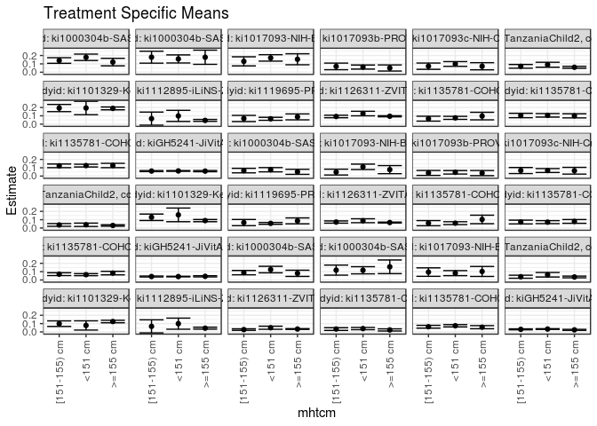

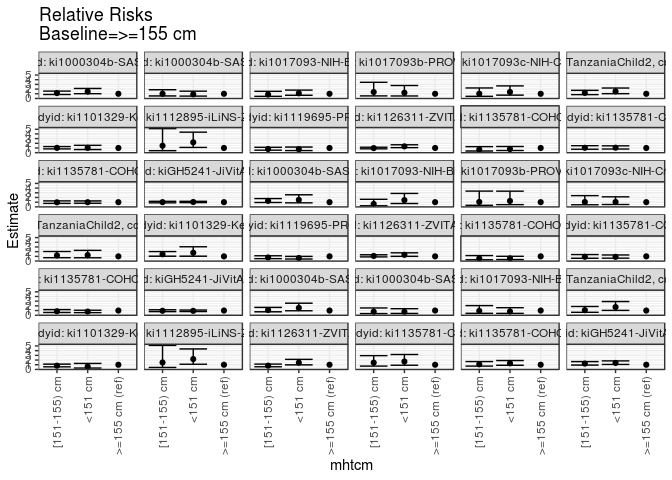

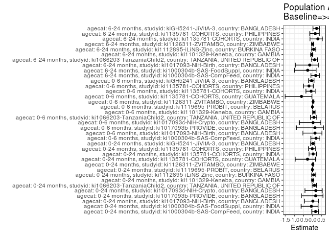

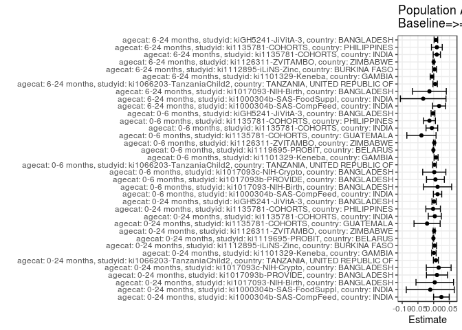

## Results Table

### Parameter: TSM

| agecat | studyid | country | intervention_level | baseline_level | estimate | ci_lower | ci_upper |
| --- | --- | --- | --- | --- | --- | --- | --- |
| 0-24 months | ki1000304b-SAS-CompFeed | INDIA | >=155 cm | NA | 0.1214789 | 0.0761790 | 0.1667787 |
| 0-24 months | ki1000304b-SAS-CompFeed | INDIA | <151 cm | NA | 0.1786448 | 0.1403009 | 0.2169886 |
| 0-24 months | ki1000304b-SAS-CompFeed | INDIA | [151-155) cm | NA | 0.1402985 | 0.1066336 | 0.1739634 |
| 0-24 months | ki1000304b-SAS-FoodSuppl | INDIA | >=155 cm | NA | 0.1794872 | 0.0942181 | 0.2647563 |
| 0-24 months | ki1000304b-SAS-FoodSuppl | INDIA | <151 cm | NA | 0.1590909 | 0.1106998 | 0.2074820 |
| 0-24 months | ki1000304b-SAS-FoodSuppl | INDIA | [151-155) cm | NA | 0.1801802 | 0.1085937 | 0.2517666 |
| 0-24 months | ki1017093-NIH-Birth | BANGLADESH | >=155 cm | NA | 0.1551724 | 0.0892309 | 0.2211139 |
| 0-24 months | ki1017093-NIH-Birth | BANGLADESH | <151 cm | NA | 0.1712707 | 0.1324298 | 0.2101117 |
| 0-24 months | ki1017093-NIH-Birth | BANGLADESH | [151-155) cm | NA | 0.1301370 | 0.0755177 | 0.1847562 |
| 0-24 months | ki1017093b-PROVIDE | BANGLADESH | >=155 cm | NA | 0.0507246 | 0.0140860 | 0.0873632 |
| 0-24 months | ki1017093b-PROVIDE | BANGLADESH | <151 cm | NA | 0.0616622 | 0.0372331 | 0.0860913 |
| 0-24 months | ki1017093b-PROVIDE | BANGLADESH | [151-155) cm | NA | 0.0696203 | 0.0299064 | 0.1093341 |
| 0-24 months | ki1017093c-NIH-Crypto | BANGLADESH | >=155 cm | NA | 0.0714286 | 0.0287396 | 0.1141175 |
| 0-24 months | ki1017093c-NIH-Crypto | BANGLADESH | <151 cm | NA | 0.0988506 | 0.0707847 | 0.1269165 |
| 0-24 months | ki1017093c-NIH-Crypto | BANGLADESH | [151-155) cm | NA | 0.0722222 | 0.0343817 | 0.1100627 |
| 0-24 months | ki1066203-TanzaniaChild2 | TANZANIA, UNITED REPUBLIC OF | >=155 cm | NA | 0.0590604 | 0.0470881 | 0.0710327 |
| 0-24 months | ki1066203-TanzaniaChild2 | TANZANIA, UNITED REPUBLIC OF | <151 cm | NA | 0.0893855 | 0.0598258 | 0.1189451 |
| 0-24 months | ki1066203-TanzaniaChild2 | TANZANIA, UNITED REPUBLIC OF | [151-155) cm | NA | 0.0704501 | 0.0482576 | 0.0926426 |
| 0-24 months | ki1101329-Keneba | GAMBIA | >=155 cm | NA | 0.1890819 | 0.1719812 | 0.2061826 |
| 0-24 months | ki1101329-Keneba | GAMBIA | <151 cm | NA | 0.1935484 | 0.1132365 | 0.2738603 |
| 0-24 months | ki1101329-Keneba | GAMBIA | [151-155) cm | NA | 0.1932515 | 0.1503810 | 0.2361221 |
| 0-24 months | ki1112895-iLiNS-Zinc | BURKINA FASO | >=155 cm | NA | 0.0448276 | 0.0330790 | 0.0565762 |
| 0-24 months | ki1112895-iLiNS-Zinc | BURKINA FASO | <151 cm | NA | 0.0989011 | 0.0320763 | 0.1657259 |
| 0-24 months | ki1112895-iLiNS-Zinc | BURKINA FASO | [151-155) cm | NA | 0.0663717 | -0.0121057 | 0.1448490 |
| 0-24 months | ki1119695-PROBIT | BELARUS | >=155 cm | NA | 0.0872001 | 0.0518410 | 0.1225591 |
| 0-24 months | ki1119695-PROBIT | BELARUS | <151 cm | NA | 0.0640000 | 0.0461518 | 0.0818482 |
| 0-24 months | ki1119695-PROBIT | BELARUS | [151-155) cm | NA | 0.0678392 | 0.0306458 | 0.1050326 |
| 0-24 months | ki1126311-ZVITAMBO | ZIMBABWE | >=155 cm | NA | 0.0947692 | 0.0882767 | 0.1012616 |
| 0-24 months | ki1126311-ZVITAMBO | ZIMBABWE | <151 cm | NA | 0.1271777 | 0.0999204 | 0.1544350 |
| 0-24 months | ki1126311-ZVITAMBO | ZIMBABWE | [151-155) cm | NA | 0.0918580 | 0.0769240 | 0.1067921 |

[output cut: 78 more lines]

### Parameter: E(Y)

| agecat | studyid | country | intervention_level | baseline_level | estimate | ci_lower | ci_upper |
| --- | --- | --- | --- | --- | --- | --- | --- |
| 0-24 months | ki1000304b-SAS-CompFeed | INDIA | NA | NA | 0.1460432 | 0.1145875 | 0.1774988 |
| 0-24 months | ki1000304b-SAS-FoodSuppl | INDIA | NA | NA | 0.1687042 | 0.1323664 | 0.2050420 |
| 0-24 months | ki1017093-NIH-Birth | BANGLADESH | NA | NA | 0.1586538 | 0.1299648 | 0.1873429 |
| 0-24 months | ki1017093b-PROVIDE | BANGLADESH | NA | NA | 0.0612855 | 0.0430966 | 0.0794744 |
| 0-24 months | ki1017093c-NIH-Crypto | BANGLADESH | NA | NA | 0.0874172 | 0.0672569 | 0.1075775 |
| 0-24 months | ki1066203-TanzaniaChild2 | TANZANIA, UNITED REPUBLIC OF | NA | NA | 0.0661297 | 0.0560993 | 0.0761601 |
| 0-24 months | ki1101329-Keneba | GAMBIA | NA | NA | 0.1898110 | 0.1742287 | 0.2053933 |
| 0-24 months | ki1112895-iLiNS-Zinc | BURKINA FASO | NA | NA | 0.0478707 | 0.0359037 | 0.0598376 |
| 0-24 months | ki1119695-PROBIT | BELARUS | NA | NA | 0.0864278 | 0.0516339 | 0.1212218 |
| 0-24 months | ki1126311-ZVITAMBO | ZIMBABWE | NA | NA | 0.0962360 | 0.0904057 | 0.1020663 |
| 0-24 months | ki1135781-COHORTS | GUATEMALA | NA | NA | 0.0760784 | 0.0615201 | 0.0906368 |
| 0-24 months | ki1135781-COHORTS | INDIA | NA | NA | 0.1034121 | 0.0897349 | 0.1170893 |
| 0-24 months | ki1135781-COHORTS | PHILIPPINES | NA | NA | 0.1254516 | 0.1136848 | 0.1372183 |
| 0-24 months | kiGH5241-JiVitA-3 | BANGLADESH | NA | NA | 0.0609979 | 0.0575023 | 0.0644934 |
| 0-6 months | ki1000304b-SAS-CompFeed | INDIA | NA | NA | 0.0636298 | 0.0408673 | 0.0863923 |
| 0-6 months | ki1017093-NIH-Birth | BANGLADESH | NA | NA | 0.0900322 | 0.0675202 | 0.1125442 |
| 0-6 months | ki1017093b-PROVIDE | BANGLADESH | NA | NA | 0.0418535 | 0.0266676 | 0.0570395 |
| 0-6 months | ki1017093c-NIH-Crypto | BANGLADESH | NA | NA | 0.0662252 | 0.0484753 | 0.0839750 |
| 0-6 months | ki1066203-TanzaniaChild2 | TANZANIA, UNITED REPUBLIC OF | NA | NA | 0.0334888 | 0.0262272 | 0.0407503 |
| 0-6 months | ki1101329-Keneba | GAMBIA | NA | NA | 0.0968041 | 0.0843285 | 0.1092796 |
| 0-6 months | ki1119695-PROBIT | BELARUS | NA | NA | 0.0850444 | 0.0501371 | 0.1199517 |
| 0-6 months | ki1126311-ZVITAMBO | ZIMBABWE | NA | NA | 0.0681168 | 0.0631263 | 0.0731073 |
| 0-6 months | ki1135781-COHORTS | GUATEMALA | NA | NA | 0.0641148 | 0.0492559 | 0.0789738 |
| 0-6 months | ki1135781-COHORTS | INDIA | NA | NA | 0.0735373 | 0.0616816 | 0.0853930 |
| 0-6 months | ki1135781-COHORTS | PHILIPPINES | NA | NA | 0.0693167 | 0.0602923 | 0.0783411 |
| 0-6 months | kiGH5241-JiVitA-3 | BANGLADESH | NA | NA | 0.0413613 | 0.0383739 | 0.0443486 |
| 6-24 months | ki1000304b-SAS-CompFeed | INDIA | NA | NA | 0.0971026 | 0.0697212 | 0.1244840 |
| 6-24 months | ki1000304b-SAS-FoodSuppl | INDIA | NA | NA | 0.1246883 | 0.0923131 | 0.1570635 |
| 6-24 months | ki1017093-NIH-Birth | BANGLADESH | NA | NA | 0.0885609 | 0.0646203 | 0.1125014 |
| 6-24 months | ki1066203-TanzaniaChild2 | TANZANIA, UNITED REPUBLIC OF | NA | NA | 0.0408060 | 0.0321006 | 0.0495115 |
| 6-24 months | ki1101329-Keneba | GAMBIA | NA | NA | 0.1195185 | 0.1063325 | 0.1327045 |
| 6-24 months | ki1112895-iLiNS-Zinc | BURKINA FASO | NA | NA | 0.0478707 | 0.0359037 | 0.0598376 |
| 6-24 months | ki1126311-ZVITAMBO | ZIMBABWE | NA | NA | 0.0345547 | 0.0306996 | 0.0384098 |
| 6-24 months | ki1135781-COHORTS | INDIA | NA | NA | 0.0336408 | 0.0254069 | 0.0418747 |
| 6-24 months | ki1135781-COHORTS | PHILIPPINES | NA | NA | 0.0669277 | 0.0576848 | 0.0761707 |
| 6-24 months | kiGH5241-JiVitA-3 | BANGLADESH | NA | NA | 0.0318896 | 0.0289915 | 0.0347877 |

### Parameter: RR

| agecat | studyid | country | intervention_level | baseline_level | estimate | ci_lower | ci_upper |
| --- | --- | --- | --- | --- | --- | --- | --- |
| 0-24 months | ki1000304b-SAS-CompFeed | INDIA | >=155 cm | >=155 cm | 1.0000000 | 1.0000000 | 1.0000000 |
| 0-24 months | ki1000304b-SAS-CompFeed | INDIA | <151 cm | >=155 cm | 1.4705830 | 1.0145558 | 2.1315873 |
| 0-24 months | ki1000304b-SAS-CompFeed | INDIA | [151-155) cm | >=155 cm | 1.1549210 | 0.8492969 | 1.5705257 |
| 0-24 months | ki1000304b-SAS-FoodSuppl | INDIA | >=155 cm | >=155 cm | 1.0000000 | 1.0000000 | 1.0000000 |
| 0-24 months | ki1000304b-SAS-FoodSuppl | INDIA | <151 cm | >=155 cm | 0.8863636 | 0.5042254 | 1.5581138 |
| 0-24 months | ki1000304b-SAS-FoodSuppl | INDIA | [151-155) cm | >=155 cm | 1.0038610 | 0.5403948 | 1.8648160 |
| 0-24 months | ki1017093-NIH-Birth | BANGLADESH | >=155 cm | >=155 cm | 1.0000000 | 1.0000000 | 1.0000000 |
| 0-24 months | ki1017093-NIH-Birth | BANGLADESH | <151 cm | >=155 cm | 1.1037446 | 0.6818311 | 1.7867360 |
| 0-24 months | ki1017093-NIH-Birth | BANGLADESH | [151-155) cm | >=155 cm | 0.8386606 | 0.4615213 | 1.5239849 |
| 0-24 months | ki1017093b-PROVIDE | BANGLADESH | >=155 cm | >=155 cm | 1.0000000 | 1.0000000 | 1.0000000 |
| 0-24 months | ki1017093b-PROVIDE | BANGLADESH | <151 cm | >=155 cm | 1.2156262 | 0.5333591 | 2.7706417 |
| 0-24 months | ki1017093b-PROVIDE | BANGLADESH | [151-155) cm | >=155 cm | 1.3725136 | 0.5467589 | 3.4453826 |
| 0-24 months | ki1017093c-NIH-Crypto | BANGLADESH | >=155 cm | >=155 cm | 1.0000000 | 1.0000000 | 1.0000000 |
| 0-24 months | ki1017093c-NIH-Crypto | BANGLADESH | <151 cm | >=155 cm | 1.3839080 | 0.7140894 | 2.6820193 |
| 0-24 months | ki1017093c-NIH-Crypto | BANGLADESH | [151-155) cm | >=155 cm | 1.0111111 | 0.4566925 | 2.2385868 |
| 0-24 months | ki1066203-TanzaniaChild2 | TANZANIA, UNITED REPUBLIC OF | >=155 cm | >=155 cm | 1.0000000 | 1.0000000 | 1.0000000 |
| 0-24 months | ki1066203-TanzaniaChild2 | TANZANIA, UNITED REPUBLIC OF | <151 cm | >=155 cm | 1.5134586 | 1.0268684 | 2.2306238 |
| 0-24 months | ki1066203-TanzaniaChild2 | TANZANIA, UNITED REPUBLIC OF | [151-155) cm | >=155 cm | 1.1928482 | 0.8201612 | 1.7348870 |
| 0-24 months | ki1101329-Keneba | GAMBIA | >=155 cm | >=155 cm | 1.0000000 | 1.0000000 | 1.0000000 |
| 0-24 months | ki1101329-Keneba | GAMBIA | <151 cm | >=155 cm | 1.0236220 | 0.6694230 | 1.5652317 |
| 0-24 months | ki1101329-Keneba | GAMBIA | [151-155) cm | >=155 cm | 1.0220521 | 0.8043240 | 1.2987184 |
| 0-24 months | ki1112895-iLiNS-Zinc | BURKINA FASO | >=155 cm | >=155 cm | 1.0000000 | 1.0000000 | 1.0000000 |
| 0-24 months | ki1112895-iLiNS-Zinc | BURKINA FASO | <151 cm | >=155 cm | 2.2062552 | 1.1131512 | 4.3727771 |
| 0-24 months | ki1112895-iLiNS-Zinc | BURKINA FASO | [151-155) cm | >=155 cm | 1.4805990 | 0.4280421 | 5.1213962 |
| 0-24 months | ki1119695-PROBIT | BELARUS | >=155 cm | >=155 cm | 1.0000000 | 1.0000000 | 1.0000000 |
| 0-24 months | ki1119695-PROBIT | BELARUS | <151 cm | >=155 cm | 0.7339444 | 0.4513006 | 1.1936045 |
| 0-24 months | ki1119695-PROBIT | BELARUS | [151-155) cm | >=155 cm | 0.7779719 | 0.5298749 | 1.1422323 |
| 0-24 months | ki1126311-ZVITAMBO | ZIMBABWE | >=155 cm | >=155 cm | 1.0000000 | 1.0000000 | 1.0000000 |
| 0-24 months | ki1126311-ZVITAMBO | ZIMBABWE | <151 cm | >=155 cm | 1.3419736 | 1.0715798 | 1.6805963 |
| 0-24 months | ki1126311-ZVITAMBO | ZIMBABWE | [151-155) cm | >=155 cm | 0.9692820 | 0.8125144 | 1.1562967 |

[output cut: 78 more lines]

### Parameter: PAR

| agecat | studyid | country | intervention_level | baseline_level | estimate | ci_lower | ci_upper |
| --- | --- | --- | --- | --- | --- | --- | --- |
| 0-24 months | ki1000304b-SAS-CompFeed | INDIA | >=155 cm | NA | 0.0245643 | -0.0003205 | 0.0494491 |
| 0-24 months | ki1000304b-SAS-FoodSuppl | INDIA | >=155 cm | NA | -0.0107830 | -0.0870591 | 0.0654930 |
| 0-24 months | ki1017093-NIH-Birth | BANGLADESH | >=155 cm | NA | 0.0034814 | -0.0561397 | 0.0631025 |
| 0-24 months | ki1017093b-PROVIDE | BANGLADESH | >=155 cm | NA | 0.0105609 | -0.0228968 | 0.0440185 |
| 0-24 months | ki1017093c-NIH-Crypto | BANGLADESH | >=155 cm | NA | 0.0159886 | -0.0234188 | 0.0553961 |
| 0-24 months | ki1066203-TanzaniaChild2 | TANZANIA, UNITED REPUBLIC OF | >=155 cm | NA | 0.0070693 | -0.0008601 | 0.0149988 |
| 0-24 months | ki1101329-Keneba | GAMBIA | >=155 cm | NA | 0.0007291 | -0.0064162 | 0.0078745 |
| 0-24 months | ki1112895-iLiNS-Zinc | BURKINA FASO | >=155 cm | NA | 0.0030431 | -0.0031079 | 0.0091941 |
| 0-24 months | ki1119695-PROBIT | BELARUS | >=155 cm | NA | -0.0007722 | -0.0017964 | 0.0002520 |
| 0-24 months | ki1126311-ZVITAMBO | ZIMBABWE | >=155 cm | NA | 0.0014669 | -0.0015476 | 0.0044813 |
| 0-24 months | ki1135781-COHORTS | GUATEMALA | >=155 cm | NA | -0.0208913 | -0.0624142 | 0.0206317 |
| 0-24 months | ki1135781-COHORTS | INDIA | >=155 cm | NA | 0.0035872 | -0.0171330 | 0.0243074 |
| 0-24 months | ki1135781-COHORTS | PHILIPPINES | >=155 cm | NA | -0.0017344 | -0.0248960 | 0.0214271 |
| 0-24 months | kiGH5241-JiVitA-3 | BANGLADESH | >=155 cm | NA | 0.0013760 | -0.0054140 | 0.0081659 |
| 0-6 months | ki1000304b-SAS-CompFeed | INDIA | >=155 cm | NA | 0.0123024 | -0.0009380 | 0.0255427 |
| 0-6 months | ki1017093-NIH-Birth | BANGLADESH | >=155 cm | NA | 0.0124459 | -0.0322217 | 0.0571136 |
| 0-6 months | ki1017093b-PROVIDE | BANGLADESH | >=155 cm | NA | 0.0056216 | -0.0227065 | 0.0339497 |
| 0-6 months | ki1017093c-NIH-Crypto | BANGLADESH | >=155 cm | NA | 0.0019395 | -0.0348689 | 0.0387478 |
| 0-6 months | ki1066203-TanzaniaChild2 | TANZANIA, UNITED REPUBLIC OF | >=155 cm | NA | 0.0026163 | -0.0030772 | 0.0083097 |
| 0-6 months | ki1101329-Keneba | GAMBIA | >=155 cm | NA | 0.0077172 | 0.0013626 | 0.0140718 |
| 0-6 months | ki1119695-PROBIT | BELARUS | >=155 cm | NA | -0.0008688 | -0.0017502 | 0.0000125 |
| 0-6 months | ki1126311-ZVITAMBO | ZIMBABWE | >=155 cm | NA | 0.0021179 | -0.0005171 | 0.0047528 |
| 0-6 months | ki1135781-COHORTS | GUATEMALA | >=155 cm | NA | -0.0388263 | -0.0852168 | 0.0075641 |
| 0-6 months | ki1135781-COHORTS | INDIA | >=155 cm | NA | -0.0057420 | -0.0243128 | 0.0128288 |
| 0-6 months | ki1135781-COHORTS | PHILIPPINES | >=155 cm | NA | -0.0133542 | -0.0321498 | 0.0054413 |
| 0-6 months | kiGH5241-JiVitA-3 | BANGLADESH | >=155 cm | NA | -0.0021699 | -0.0082688 | 0.0039291 |
| 6-24 months | ki1000304b-SAS-CompFeed | INDIA | >=155 cm | NA | 0.0173252 | -0.0032618 | 0.0379123 |
| 6-24 months | ki1000304b-SAS-FoodSuppl | INDIA | >=155 cm | NA | -0.0332065 | -0.1055377 | 0.0391248 |
| 6-24 months | ki1017093-NIH-Birth | BANGLADESH | >=155 cm | NA | -0.0134799 | -0.0670546 | 0.0400948 |
| 6-24 months | ki1066203-TanzaniaChild2 | TANZANIA, UNITED REPUBLIC OF | >=155 cm | NA | 0.0046905 | -0.0022636 | 0.0116446 |
| 6-24 months | ki1101329-Keneba | GAMBIA | >=155 cm | NA | -0.0052865 | -0.0108741 | 0.0003010 |
| 6-24 months | ki1112895-iLiNS-Zinc | BURKINA FASO | >=155 cm | NA | 0.0030431 | -0.0031079 | 0.0091941 |
| 6-24 months | ki1126311-ZVITAMBO | ZIMBABWE | >=155 cm | NA | -0.0000792 | -0.0020397 | 0.0018813 |
| 6-24 months | ki1135781-COHORTS | INDIA | >=155 cm | NA | 0.0099182 | -0.0016419 | 0.0214783 |
| 6-24 months | ki1135781-COHORTS | PHILIPPINES | >=155 cm | NA | 0.0101291 | -0.0069937 | 0.0272519 |
| 6-24 months | kiGH5241-JiVitA-3 | BANGLADESH | >=155 cm | NA | 0.0072119 | 0.0015226 | 0.0129012 |

### Parameter: PAF

| agecat | studyid | country | intervention_level | baseline_level | estimate | ci_lower | ci_upper |
| --- | --- | --- | --- | --- | --- | --- | --- |
| 0-24 months | ki1000304b-SAS-CompFeed | INDIA | >=155 cm | NA | 0.1681988 | -0.0376944 | 0.3332400 |
| 0-24 months | ki1000304b-SAS-FoodSuppl | INDIA | >=155 cm | NA | -0.0639168 | -0.6271203 | 0.3043422 |
| 0-24 months | ki1017093-NIH-Birth | BANGLADESH | >=155 cm | NA | 0.0219436 | -0.4362325 | 0.3339558 |
| 0-24 months | ki1017093b-PROVIDE | BANGLADESH | >=155 cm | NA | 0.1723224 | -0.5965976 | 0.5709312 |
| 0-24 months | ki1017093c-NIH-Crypto | BANGLADESH | >=155 cm | NA | 0.1829004 | -0.4157638 | 0.5284159 |
| 0-24 months | ki1066203-TanzaniaChild2 | TANZANIA, UNITED REPUBLIC OF | >=155 cm | NA | 0.1069007 | -0.0203298 | 0.2182662 |
| 0-24 months | ki1101329-Keneba | GAMBIA | >=155 cm | NA | 0.0038413 | -0.0345227 | 0.0407827 |
| 0-24 months | ki1112895-iLiNS-Zinc | BURKINA FASO | >=155 cm | NA | 0.0635692 | -0.0699048 | 0.1803918 |
| 0-24 months | ki1119695-PROBIT | BELARUS | >=155 cm | NA | -0.0089348 | -0.0193427 | 0.0013668 |
| 0-24 months | ki1126311-ZVITAMBO | ZIMBABWE | >=155 cm | NA | 0.0152423 | -0.0165739 | 0.0460628 |
| 0-24 months | ki1135781-COHORTS | GUATEMALA | >=155 cm | NA | -0.2746017 | -0.9528085 | 0.1680651 |
| 0-24 months | ki1135781-COHORTS | INDIA | >=155 cm | NA | 0.0346884 | -0.1879377 | 0.2155932 |
| 0-24 months | ki1135781-COHORTS | PHILIPPINES | >=155 cm | NA | -0.0138257 | -0.2163271 | 0.1549621 |
| 0-24 months | kiGH5241-JiVitA-3 | BANGLADESH | >=155 cm | NA | 0.0225576 | -0.0952805 | 0.1277179 |
| 0-6 months | ki1000304b-SAS-CompFeed | INDIA | >=155 cm | NA | 0.1933427 | -0.0884344 | 0.4021725 |
| 0-6 months | ki1017093-NIH-Birth | BANGLADESH | >=155 cm | NA | 0.1382389 | -0.5307819 | 0.5148674 |
| 0-6 months | ki1017093b-PROVIDE | BANGLADESH | >=155 cm | NA | 0.1343168 | -0.8884265 | 0.6031577 |
| 0-6 months | ki1017093c-NIH-Crypto | BANGLADESH | >=155 cm | NA | 0.0292857 | -0.7208215 | 0.4524207 |
| 0-6 months | ki1066203-TanzaniaChild2 | TANZANIA, UNITED REPUBLIC OF | >=155 cm | NA | 0.0781242 | -0.1076211 | 0.2327205 |
| 0-6 months | ki1101329-Keneba | GAMBIA | >=155 cm | NA | 0.0797200 | 0.0123747 | 0.1424730 |
| 0-6 months | ki1119695-PROBIT | BELARUS | >=155 cm | NA | -0.0102163 | -0.0189529 | -0.0015546 |
| 0-6 months | ki1126311-ZVITAMBO | ZIMBABWE | >=155 cm | NA | 0.0310915 | -0.0083136 | 0.0689567 |
| 0-6 months | ki1135781-COHORTS | GUATEMALA | >=155 cm | NA | -0.6055751 | -1.5029506 | -0.0299330 |
| 0-6 months | ki1135781-COHORTS | INDIA | >=155 cm | NA | -0.0780825 | -0.3623184 | 0.1468501 |
| 0-6 months | ki1135781-COHORTS | PHILIPPINES | >=155 cm | NA | -0.1926552 | -0.4959099 | 0.0491230 |
| 0-6 months | kiGH5241-JiVitA-3 | BANGLADESH | >=155 cm | NA | -0.0524615 | -0.2105972 | 0.0850176 |
| 6-24 months | ki1000304b-SAS-CompFeed | INDIA | >=155 cm | NA | 0.1784218 | -0.0832963 | 0.3769103 |
| 6-24 months | ki1000304b-SAS-FoodSuppl | INDIA | >=155 cm | NA | -0.2663158 | -0.9979556 | 0.1974017 |
| 6-24 months | ki1017093-NIH-Birth | BANGLADESH | >=155 cm | NA | -0.1522109 | -0.9459907 | 0.3177820 |
| 6-24 months | ki1066203-TanzaniaChild2 | TANZANIA, UNITED REPUBLIC OF | >=155 cm | NA | 0.1149456 | -0.0709997 | 0.2686073 |
| 6-24 months | ki1101329-Keneba | GAMBIA | >=155 cm | NA | -0.0442317 | -0.0918533 | 0.0013129 |
| 6-24 months | ki1112895-iLiNS-Zinc | BURKINA FASO | >=155 cm | NA | 0.0635692 | -0.0699048 | 0.1803918 |
| 6-24 months | ki1126311-ZVITAMBO | ZIMBABWE | >=155 cm | NA | -0.0022921 | -0.0606655 | 0.0528688 |
| 6-24 months | ki1135781-COHORTS | INDIA | >=155 cm | NA | 0.2948258 | -0.1361737 | 0.5623286 |
| 6-24 months | ki1135781-COHORTS | PHILIPPINES | >=155 cm | NA | 0.1513440 | -0.1462308 | 0.3716649 |
| 6-24 months | kiGH5241-JiVitA-3 | BANGLADESH | >=155 cm | NA | 0.2261517 | 0.0281181 | 0.3838334 |